Drowsy True

----------------------------

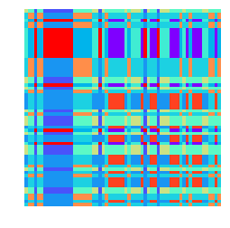

34

A_M1038MF01_3S3RNA

Drowsy True

----------------------------

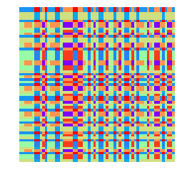

35

A_M1039MF02_3S1RNA

Drowsy True

----------------------------

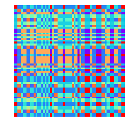

36

A_M1039MF02_3S1RNA

Drowsy True

----------------------------

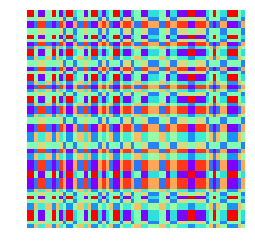

37

A_M1039MF02_3S1RNA

Drowsy True

----------------------------

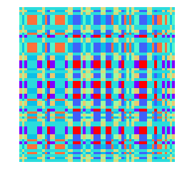

38

A_M1039MF02_3S1RNA

Drowsy True

----------------------------

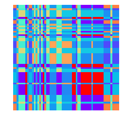

39

A_M1046MF05_2S3RNA

Drowsy True

----------------------------

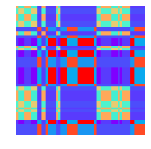

40

A_M1047MF06_2S2RNA

Drowsy True

----------------------------

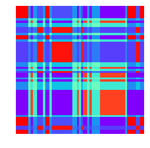

41

A_M1047MF06_2S2RNA

Drowsy True

----------------------------

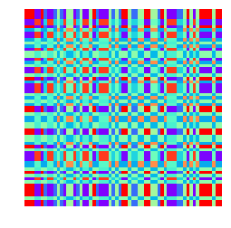

42

A_M1047MF06_3S1RNA

Drowsy True

----------------------------

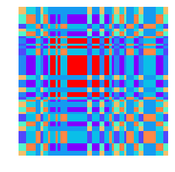

43

A_M1047MF06_3S1RNA

Drowsy True

----------------------------

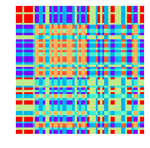

44

A_M1067OF04_2S2RNA

Drowsy True

----------------------------

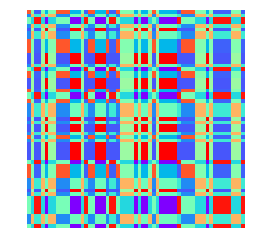

45

A_M1122YF05_2S3RNA

Drowsy True

----------------------------

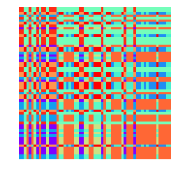

46

A_M1127MM02_2S3RNA

Drowsy True

----------------------------

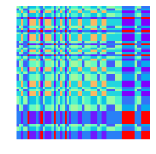

47

A_M1143MF04_2S2RNA

Drowsy True

----------------------------

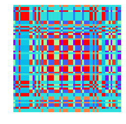

48

A_M1001YM01_1S1RNA

Drowsy False

----------------------------

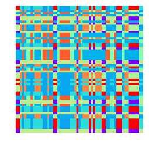

49

A_M1001YM01_1S1RNA

Drowsy False

----------------------------

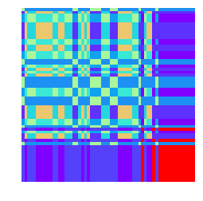

50

A_M1001YM01_1S1RNA

Drowsy False

----------------------------

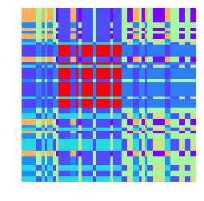

51

A_M1001YM01_1S1RNA

Drowsy False

----------------------------

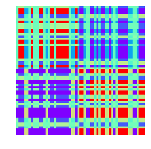

52

A_M1001YM01_1S1RNA

Drowsy False

----------------------------

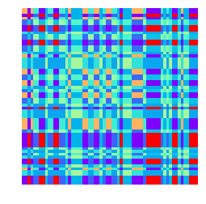

53

A_M1001YM01_1S1RNA

Drowsy False

----------------------------

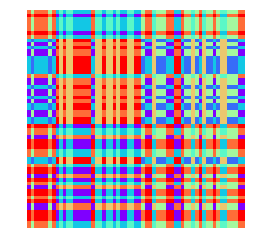

54

A_M1001YM01_1S1RNA

Drowsy False

----------------------------

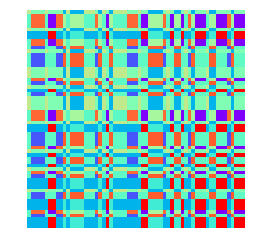

55

A_M1001YM01_1S1RNA

Drowsy False

----------------------------

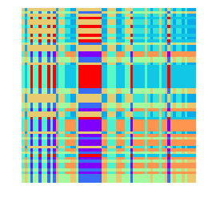

56

A_M1001YM01_1S1RNA

Drowsy False

----------------------------

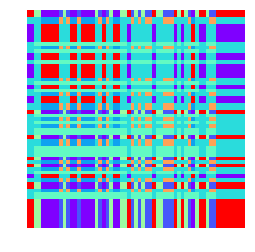

57

A_M1003YM02_1S2RNA

Drowsy False

----------------------------

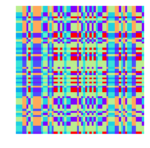

58

A_M1003YM02_1S2RNA

Drowsy False

----------------------------

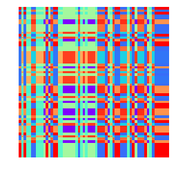

59

A_M1003YM02_1S2RNA

Drowsy False

----------------------------

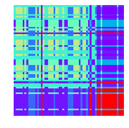

60

A_M1003YM02_1S2RNA

Drowsy False

----------------------------

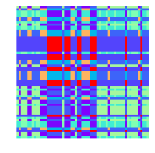

61

A_M1003YM02_1S2RNA

Drowsy False

----------------------------

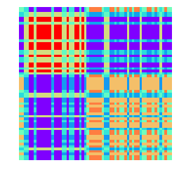

62

A_M1003YM02_1S2RNA

Drowsy False

----------------------------

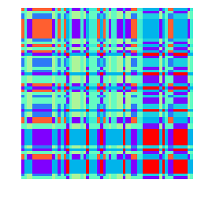

63

A_M1003YM02_1S2RNA

Drowsy False

----------------------------

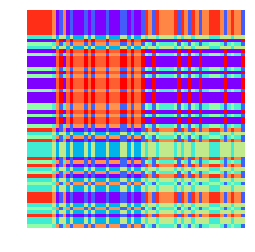

64

A_M1003YM02_1S2RNA

Drowsy False

----------------------------

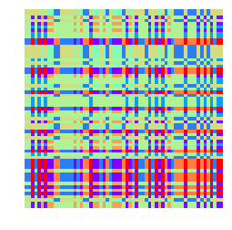

65

A_M1003YM02_1S2RNA

Drowsy False

----------------------------

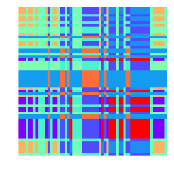

66

A_M1003YM02_1S2RNA

Drowsy False

----------------------------

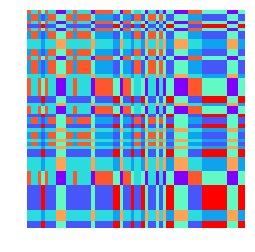

67

A_M1014YF01_3S3RNA

Drowsy False

----------------------------

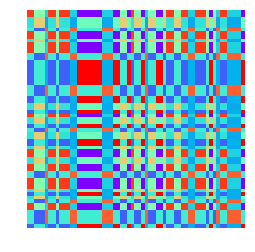

68